# Bootstrapping

```r
knitr::opts_chunk$set(echo = TRUE)
```

# Bootstrapping

```r
library(mosaic)
library(quantmod)
library(foreach)
```

```r
#Import the ETFs and use getSymboles to get their prices from 2007

mystocks = c("SPY", "TLT", "LQD", "EEM", "VNQ")
myprices = getSymbols(mystocks, from = "2007-01-01")
```

[output not shown]

[output not shown]

```r
for(ticker in mystocks) {
    expr = paste0(ticker, "a = adjustOHLC(", ticker, ")")
    eval(parse(text=expr))
}
```

```r
# Combine all the returns into a single matrix

all_returns = cbind(    ClCl(SPYa),
                                ClCl(TLTa),
                                ClCl(LQDa),
                                ClCl(EEMa),
                                ClCl(VNQa))
head(all_returns)
```

```
##                ClCl.SPYa    ClCl.TLTa     ClCl.LQDa    ClCl.EEMa
## 2007-01-03            NA           NA            NA           NA
## 2007-01-04  0.0021221123  0.006063328  0.0075152938 -0.013809353
## 2007-01-05 -0.0079763183 -0.004352668 -0.0006526807 -0.029238205
## 2007-01-08  0.0046250821  0.001793566 -0.0002798843  0.007257535
## 2007-01-09 -0.0008498831  0.000000000  0.0001866169 -0.022336235
## 2007-01-10  0.0033315799 -0.004475797 -0.0013063264 -0.002303160
##               ClCl.VNQa
## 2007-01-03           NA
## 2007-01-04  0.001296655
## 2007-01-05 -0.018518518
## 2007-01-08  0.001451392
## 2007-01-09  0.012648208
## 2007-01-10  0.012880523
```

```r
all_returns = as.matrix(na.omit(all_returns))
```

```r
# The sample correlation matrix
cor(all_returns)
```

```
##            ClCl.SPYa  ClCl.TLTa  ClCl.LQDa   ClCl.EEMa   ClCl.VNQa
## ClCl.SPYa  1.0000000 -0.4434811 0.10255294  0.40329628  0.77671377
## ClCl.TLTa -0.4434811  1.0000000 0.42152831 -0.16861612 -0.26520718
## ClCl.LQDa  0.1025529  0.4215283 1.00000000  0.08800942  0.06703847
## ClCl.EEMa  0.4032963 -0.1686161 0.08800942  1.00000000  0.29131651
## ClCl.VNQa  0.7767138 -0.2652072 0.06703847  0.29131651  1.00000000
```

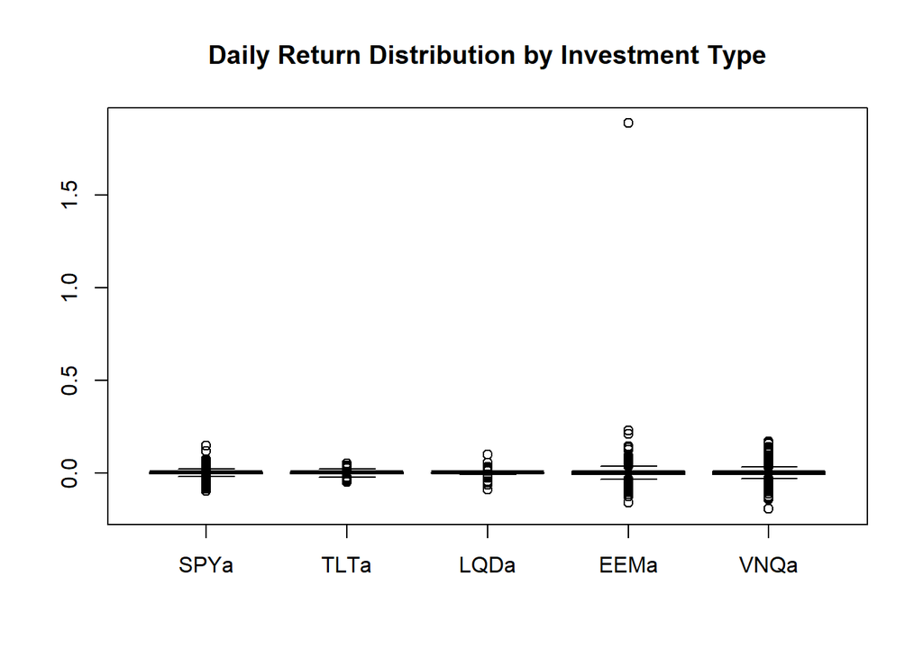

```r
boxplot(all_returns, main="Daily Return Distribution by Investment Type", names= c("SPYa","TLTa","LQDa","EEMa","VNQa"))
```

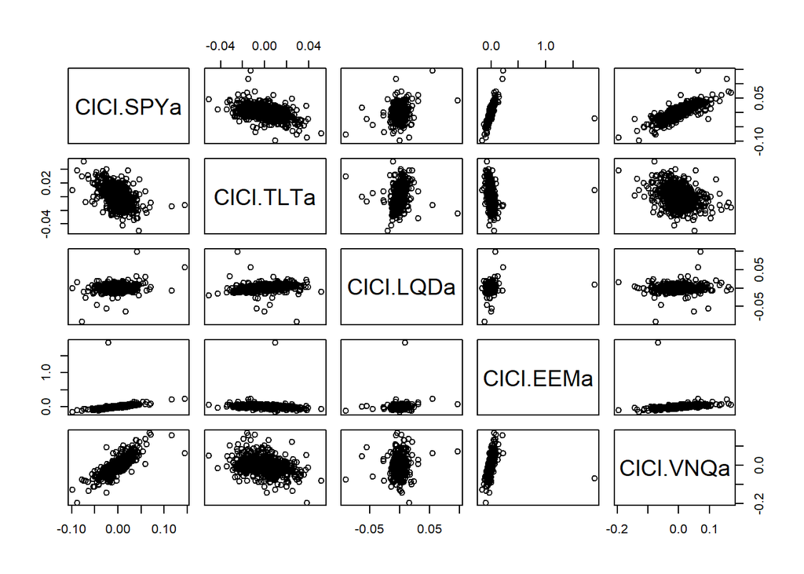

```r
# Compute the returns from the closing prices
pairs(all_returns)
```

The correlations suggest that LQD has almost zero correlations with all other assets except TLT.

Looking at the pairs plot of returns and the boxplots, the safest investments are Investment-grade corporate bonds (LQD), US Treasury bonds (TLT) and US domestic equities (QPY) . Their inter-quartile range (IQR, which captures the middle 50% of the data) is < +/-0.005. In looking at the pair plots, these assets also have relatively tight clusters, which corresponds to the lowest risk and deviation.

The riskier investments are emerging market equities (EEM) and real estate (VNQ), with IQRs between ~+/- 0.01.There is a tradeoff between return and risk, with the higher risk investments yielding higher potential returns.

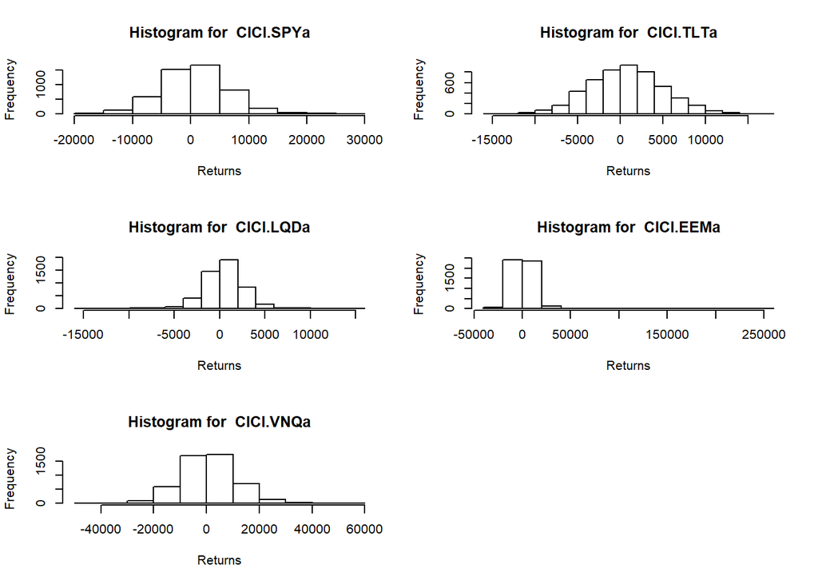

```r
# Get the standard deviations and Value at risk for each of the five ETFs for comparision

VaR_all=NULL
mean_all=NULL
sd_all=NULL
par(mfrow=c(3,2))
n_days=20
set.seed(1)
for (j in 1:ncol(all_returns)){
  # Now simulate many different possible years
  sim = foreach(i=1:5000, .combine='rbind') %do% {
    totalwealth = 100000
    weights = 1
    holdings = weights * totalwealth
    wealthtracker = rep(0, n_days) # Set up a placeholder to track total wealth
    for(today in 1:n_days) {
      return.today = resample(all_returns[,j], 1, orig.ids=FALSE)
      holdings = holdings + holdings*return.today
      totalwealth = sum(holdings)
      wealthtracker[today] = totalwealth
    }
    wealthtracker
  }

  hist(sim[,n_days]- 100000, main = paste('Histogram for ',colnames(all_returns)[j],sep=" "), xlab = "Returns")

  # Calculate 5% value at risk
  VaR_all[j] = quantile(sim[,n_days], 0.05) - 100000
  mean_all[j] = mean(sim[,n_days])
  sd_all[j] = sd(sim[,n_days])
}
```

```r
VaR_all
```

```
## [1]  -8457.867  -6112.391  -2971.231 -13418.160 -14965.009
```

```r
mean_all
```

```
## [1] 100780.3 100693.6 100464.9 101894.7 100822.1
```

```r
sd_all
```

```
## [1]  5729.955  4259.425  2348.712 18794.654 10216.446
```

To further support our previous findings, we see that EEM and VNQ have very high standard deviations (standard deviation being a measure or risk) and value at risk values compared to LQD, TLT and SPY. So if an investor is looking for a high return, he/she should invest in these ETFs which have the highest risk.

We also see that LQD seems to be the ETF with the least value at risk and least standard deviation. So we will look to give this ETF a relatively higher weight in our safe portfolio.

### Even Split Portfolio

Here we give equal weights of 0.2 each to all the five ETFs.

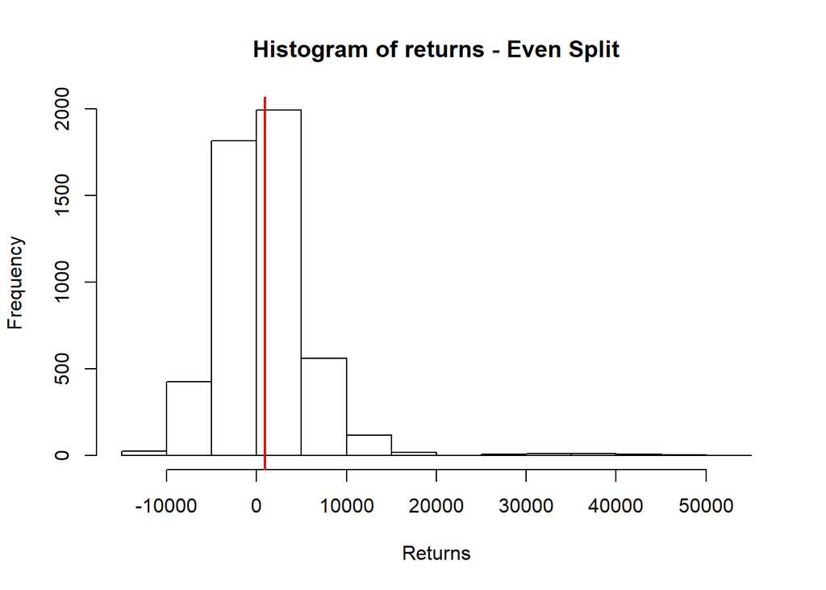

```r
initialwealth=100000
sim_even = foreach(i=1:5000, .combine='rbind') %do% {
totalwealth_even = 100000
n_days = 20
weights_even = c(0.2, 0.2, 0.2, 0.2, 0.2)
holdings_even = weights_even * totalwealth_even
wealthtracker_even = rep(0, n_days) # Set up a placeholder to track total wealth

for(today in 1:n_days) {
return.today = resample(all_returns, 1, orig.ids=FALSE)
holdings_even = holdings_even + holdings_even*return.today
totalwealth_even = sum(holdings_even)
wealthtracker_even[today] = totalwealth_even
}
wealthtracker_even
}

hist(sim_even[,n_days]- 100000, main = "Histogram of returns - Even Split", xlab = "Returns")
abline(v=mean(sim_even[,n_days]- 100000), col="red", lwd=2)
```

### Safer Portfolio

For a safer choice than the even split above, we decided on only investing in the three safest invesements; US domestic markets, US Treasury bonds, and corporate bonds. This will minimize the chance of a big loss, but will also limit potential for large gains. Historically the bond market has been less vulnerable to price swings or volatility than the stock market.

A safer stock would be the one which does not vary much due to changes in other stocks and has positive returns. In this case, LQD is one such stock with close to zero correlation with all other stocks except TLT.

Also, among LQD, TLT and SPY, LQD has the least standard deviation (least risk) so we give a higher weight of 0.5 to LQD and lesser weight of 0.2 to SPY.

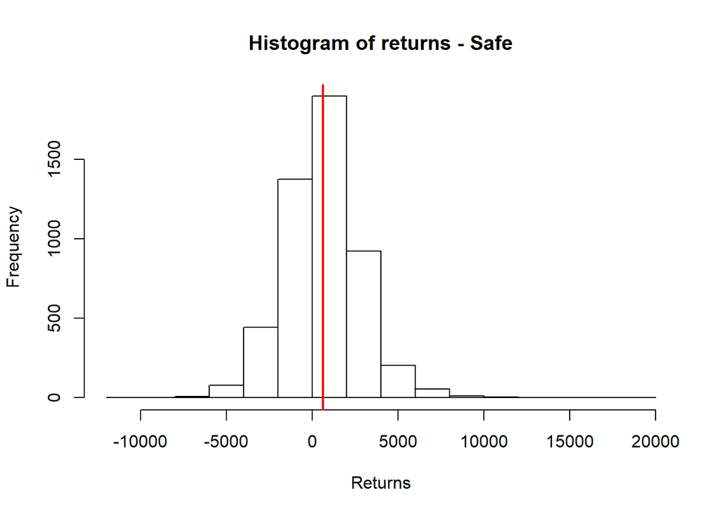

```r
initialwealth=100000
sim_safe = foreach(i=1:5000, .combine='rbind') %do% {
totalwealth_safe = 100000
n_days = 20
weights_safe = c(0.2, 0.3, 0.5, 0, 0)
holdings_safe = weights_safe * totalwealth_safe
wealthtracker_safe = rep(0, n_days) # Set up a placeholder to track total wealth
for(today in 1:n_days) {
return.today = resample(all_returns, 1, orig.ids=FALSE)
holdings_safe = holdings_safe + holdings_safe*return.today
totalwealth_safe = sum(holdings_safe)
wealthtracker_safe[today] = totalwealth_safe
}
wealthtracker_safe
}
hist(sim_safe[,n_days]- 100000, main = "Histogram of returns - Safe", xlab = "Returns")
abline(v=mean(sim_safe[,n_days]- 100000), col="red", lwd=2)
```

### Riskier Portfolio

For the risky portfolio, we decided on investing an even split in the two riskiest investments from above; emerging market equities (EEM) and real estate (VNQ) . This will maximize the chance at a big return, but will also open the possibility for severe losses.

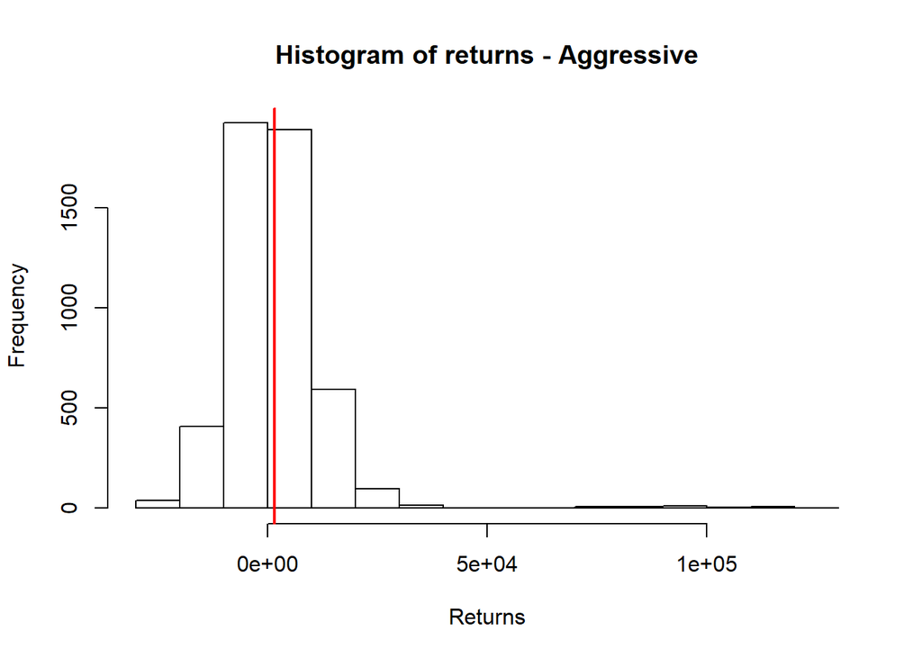

```r
initialwealth=100000
sim_risk = foreach(i=1:5000, .combine='rbind') %do% {
totalwealth_risk = 100000
n_days = 20
weights_risk = c(0, 0, 0, 0.5, 0.5)
holdings_risk = weights_risk * totalwealth_risk
wealthtracker_risk = rep(0, n_days) # Set up a placeholder to track total wealth
for(today in 1:n_days) {
return.today = resample(all_returns, 1, orig.ids=FALSE)
holdings_risk = holdings_risk + holdings_risk*return.today
totalwealth_risk = sum(holdings_risk)
wealthtracker_risk[today] = totalwealth_risk
}
wealthtracker_risk
}
hist(sim_risk[,n_days]- 100000, main = "Histogram of returns - Aggressive", xlab = "Returns")
abline(v=mean(sim_risk[,n_days]- 100000), col="red", lwd=2)
```

```r
names = c("Even","Safe","Aggresive")
average = c(mean(sim_even[,20]), mean(sim_safe[,20]), mean(sim_risk[,20]))
profit_prob = c(sum(sim_even[,20]>100000)/5000, sum(sim_safe[,20]>100000)/5000, sum(sim_risk[,20]>100000)/5000)
VaR = c((quantile(sim_even[,n_days], 0.05) - 100000), (quantile(sim_safe[,n_days], 0.05) - 100000), (quantile(sim_risk[,n_days], 0.05) - 100000))

data.frame(names, VaR)
```

```
##       names        VaR
## 1      Even  -6242.313
## 2      Safe  -2892.832
## 3 Aggresive -12890.714
```

The aggressive portfolio is definitely the riskiest with the highest absolute value at risk. The largest percentage of the portfolio value that one might lose over a given time period is 13000 dollars for a risky portfolio, to a 5% degree of certainty.

The safe portfolio has the least absolute value at risk. The largest percentage of the portfolio value that one might lose over a given time period is just 2900 dollars for a safe portfolio, to a 5% degree of certainty.

```r
data.frame(names, average, profit_prob)
```

```
##       names  average profit_prob
## 1      Even 100912.3      0.5460
## 2      Safe 100624.5      0.6186
## 3 Aggresive 101642.5      0.5264
```

Average simulated values of the portfolios and the probability of making a profit can help make investment decisions.

The aggressive portfolio which gave equal weights to the two riskiest ETFs has the highest average return (high risk-high return) but only 52% of portfolios would result in a profit.

The safe portfolio that gave maximum weight to LQD and lesser weights to TLT and SPY, has least average profit, but 61% of portfolios would result in a profit.

So the investor faces this risk-return tradeoff at the portfolio level while considering investment decisions.